# Final Assignment

Hans Hellén, hans.hellen@hellen.me

Dec 18 2017

```r
library(MASS)
library(dplyr)
library(ggplot2)
library(knitr)
library(tidyr)
library(GGally)
boston_final <- read.csv("data/boston_final.csv", header=T, sep=",")

#NOTE: some functions might have be commented out to make the knitted output more simple.
```

# Introduction

Originally the data I will use is from Boston dataset from R package/library called MASS. This data frame is about housing values in suburbs of Boston. The original variables are explained on [this](https://stat.ethz.ch/R-manual/R-devel/library/MASS/html/Boston.html) webpage.

In short the variables are about crime rate per capita, urban planning, housing, air pollution, economy, school environment, skin colour. It is useful to have look at the original [research article](https://dx.doi.org/10.1016/0095-0696%2878%2990006-2), that was about air pollution, the housing values (variable medv) and willingness to pay for cleaner air.

I will fit a linear regression model to find out **what variables explain best the highest criminal activity occurring in Boston**. According the knowledge gained from LDA biplot done in RStudio exercise 4, my hypothesis is that the explanatory variables *rad, lstat, tax, ptratio, black* and *rm* can be used to best predict high crime rate.

# Data Wrangling

[Here](https://github.com/daphnia/IODS-final/blob/master/data/create_final.R) is my data wrangling script.

As can clearly be seen from a histogram of the original data below, there is a small bunch of suburbs with extreme crime rates per capita.

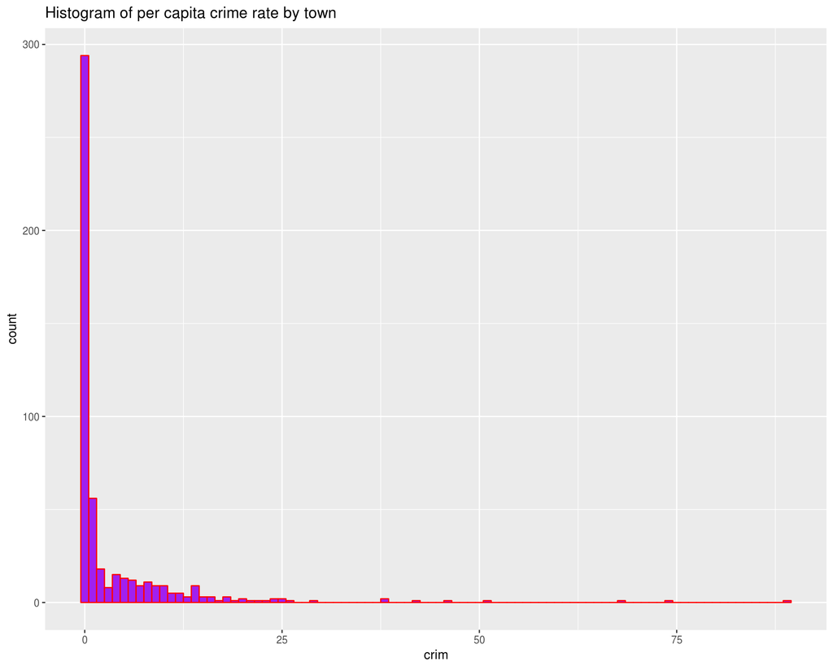

Histogram from original data concerning Boston

```r
data("Boston")
p_crim <- ggplot(Boston, aes(crim)) + geom_histogram(binwidth = 1, fill="purple", colour="red") + ggtitle("Histogram of per capita crime rate by town")
p_crim
```

In the following analysis the focus is on the highest quantile of crime rates.

# Analysis

Here is summary of my data used here:

```r
glimpse(boston_final)
```

```
## Observations: 127
## Variables: 13
## $ crim    <dbl> 4.09740, 8.98296, 3.84970, 5.20177, 4.26131, 4.54192, ...
## $ zn      <int> 0, 0, 0, 0, 0, 0, 0, 0, 0, 0, 0, 0, 0, 0, 0, 0, 0, 0, ...
## $ indus   <dbl> 19.58, 18.10, 18.10, 18.10, 18.10, 18.10, 18.10, 18.10...
## $ nox     <dbl> 0.871, 0.770, 0.770, 0.770, 0.770, 0.770, 0.770, 0.770...
## $ rm      <dbl> 5.468, 6.212, 6.395, 6.127, 6.112, 6.398, 6.251, 5.362...
## $ age     <dbl> 100.0, 97.4, 91.0, 83.4, 81.3, 88.0, 91.1, 96.2, 89.0,...
## $ dis     <dbl> 1.4118, 2.1222, 2.5052, 2.7227, 2.5091, 2.5182, 2.2955...
## $ rad     <int> 5, 24, 24, 24, 24, 24, 24, 24, 24, 24, 24, 24, 24, 24,...
## $ tax     <int> 403, 666, 666, 666, 666, 666, 666, 666, 666, 666, 666,...
## $ ptratio <dbl> 14.7, 20.2, 20.2, 20.2, 20.2, 20.2, 20.2, 20.2, 20.2, ...
## $ black   <dbl> 396.90, 377.73, 391.34, 395.43, 390.74, 374.56, 350.65...
## $ lstat   <dbl> 26.42, 17.60, 13.27, 11.48, 12.67, 7.79, 14.19, 10.19,...
## $ medv    <dbl> 15.6, 17.8, 21.7, 22.7, 22.6, 25.0, 19.9, 20.8, 16.8, ...
```

```r
summary(boston_final)
```

```
##       crim              zn        indus            nox
##  Min.   : 3.678   Min.   :0   Min.   :18.10   Min.   :0.532
##  1st Qu.: 5.823   1st Qu.:0   1st Qu.:18.10   1st Qu.:0.631
##  Median : 9.329   Median :0   Median :18.10   Median :0.693
##  Mean   :13.144   Mean   :0   Mean   :18.11   Mean   :0.677
##  3rd Qu.:14.377   3rd Qu.:0   3rd Qu.:18.10   3rd Qu.:0.713
##  Max.   :88.976   Max.   :0   Max.   :19.58   Max.   :0.871
##        rm             age              dis             rad
##  Min.   :3.561   Min.   : 53.20   Min.   :1.130   Min.   : 5.00
##  1st Qu.:5.665   1st Qu.: 87.90   1st Qu.:1.577   1st Qu.:24.00
##  Median :6.167   Median : 94.80   Median :1.914   Median :24.00
##  Mean   :5.996   Mean   : 91.45   Mean   :1.999   Mean   :23.85
##  3rd Qu.:6.414   3rd Qu.: 99.00   3rd Qu.:2.320   3rd Qu.:24.00
##  Max.   :7.393   Max.   :100.00   Max.   :3.546   Max.   :24.00
##       tax           ptratio          black            lstat
##  Min.   :403.0   Min.   :14.70   Min.   :  0.32   Min.   : 2.96
##  1st Qu.:666.0   1st Qu.:20.20   1st Qu.:129.39   1st Qu.:14.68
##  Median :666.0   Median :20.20   Median :374.56   Median :18.13
##  Mean   :663.9   Mean   :20.16   Mean   :284.96   Mean   :19.00
##  3rd Qu.:666.0   3rd Qu.:20.20   3rd Qu.:395.56   3rd Qu.:23.28
##  Max.   :666.0   Max.   :20.20   Max.   :396.90   Max.   :37.97
##       medv
##  Min.   : 5.00
##  1st Qu.:10.95
##  Median :14.10
##  Mean   :16.16
##  3rd Qu.:19.10
##  Max.   :50.00
```

Scatter plots of all the variables are presented in a matrix below.

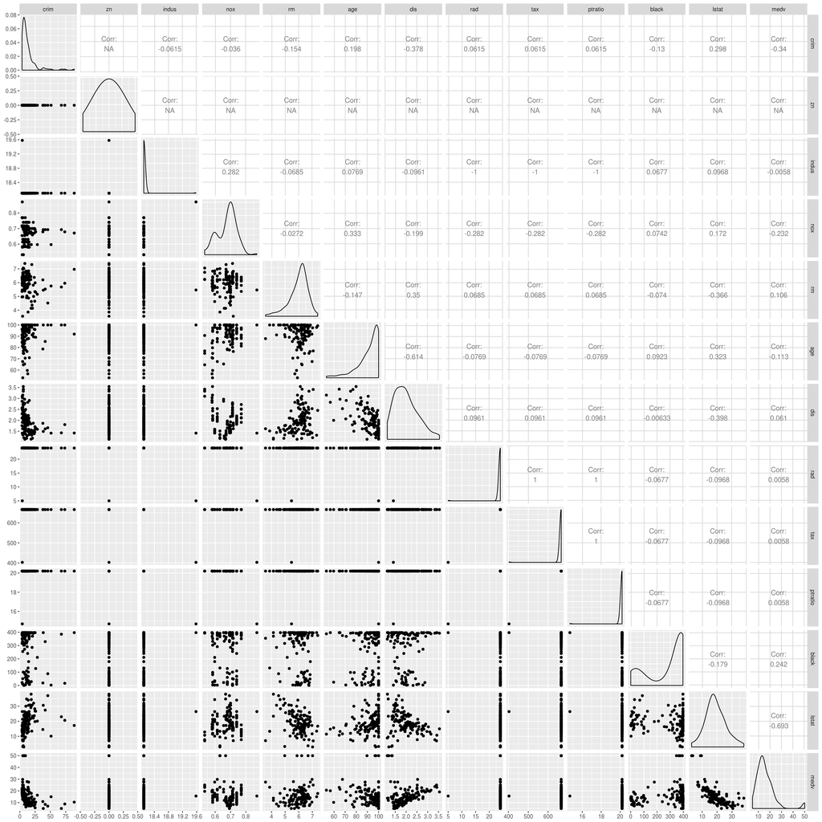

**Tip**: Right click the image of plots and choose “Show image” to zoom closer.

```r
p_b_f <- ggpairs(boston_final, lower = list(combo = wrap("facethist", bins = 20)))
p_b_f
```

The date set has observations from 127 different towns. The target (also known as dependent, response) variable is chosen to be crim (per capita crime rate by town). Keep in mind that the variable black gets smaller values as the proportion of black population increases.

From the summaries and graphics above we can already see some interesting findings concerning the high crime towns:

- The *Zn* variable (proportion of residential land zoned for lots over 25,000 sq.ft.) has zero observations. We can conclude that in areas with big apartment houses, the high crime rate is improbable. So Zn will be left out from the modelling.
- Also there seems to be a separation into communities for black people and communities for white people. This can be seen from the scatter plot graphics: the density curve of *black* has two peaks.
- Also looking at the scatter plot graphics and the the density curve of *medv* with two peaks. There seems to be a small amount of towns, where the median value of owner-occupied homes are exceptionally high.
- Most of the houses are old (*age*).
- The variable *indus*, *rad*, *tax* and *ptratio* has only one observation differing from all the others, so they are not suitable for linear regression analysis. So, my hypothesis just got weakened a lot.

## Regression models

Here is regression models with multiple explanatory variables:

```r
my_model <- lm(crim ~ . - zn - indus - rad - tax - ptratio, data = boston_final)
summary(my_model)
```

```
##
## Call:
## lm(formula = crim ~ . - zn - indus - rad - tax - ptratio, data = boston_final)
##
## Residuals:
##     Min      1Q  Median      3Q     Max
## -13.898  -5.855  -1.563   3.187  64.776
##
## Coefficients:
##               Estimate Std. Error t value Pr(>|t|)
## (Intercept)  89.479345  22.027742   4.062 8.75e-05 ***
## nox         -43.034396  18.010821  -2.389   0.0184 *
## rm           -0.429649   1.672788  -0.257   0.7977
## age          -0.017064   0.136403  -0.125   0.9007
## dis         -11.323013   2.612957  -4.333 3.09e-05 ***
## black        -0.003270   0.007235  -0.452   0.6521
## lstat        -0.392056   0.249161  -1.574   0.1183
## medv         -0.745837   0.180252  -4.138 6.57e-05 ***
## ---
## Signif. codes:  0 '***' 0.001 '**' 0.01 '*' 0.05 '.' 0.1 ' ' 1
##
## Residual standard error: 11.35 on 119 degrees of freedom
## Multiple R-squared:  0.2963, Adjusted R-squared:  0.2549
## F-statistic: 7.159 on 7 and 119 DF,  p-value: 3.864e-07
```

Second try:

```r
my_model2 <- lm(crim ~ . - zn - indus - rad - tax - ptratio - age - rm - black - lstat, data = boston_final)
summary(my_model2)
```

```
##
## Call:
## lm(formula = crim ~ . - zn - indus - rad - tax - ptratio - age -
##     rm - black - lstat, data = boston_final)
##
## Residuals:
##     Min      1Q  Median      3Q     Max
## -13.744  -5.850  -1.655   2.643  66.856
##
## Coefficients:
##             Estimate Std. Error t value Pr(>|t|)
## (Intercept)  69.8120    13.3973   5.211 7.68e-07 ***
## nox         -42.4109    17.1115  -2.479   0.0145 *
## dis          -9.5330     1.8803  -5.070 1.42e-06 ***
## medv         -0.5510     0.1198  -4.597 1.05e-05 ***
## ---
## Signif. codes:  0 '***' 0.001 '**' 0.01 '*' 0.05 '.' 0.1 ' ' 1
##
## Residual standard error: 11.29 on 123 degrees of freedom
## Multiple R-squared:  0.2799, Adjusted R-squared:  0.2623
## F-statistic: 15.93 on 3 and 123 DF,  p-value: 8.182e-09
```

From the summary above it can be seen that

- when living far away from five Boston employment centres (*dis*), it predicts lower crime rate,
- when the values of homes (*medv*) increases, it predicts lower crime rate,
- when content of nitrous oxides (*nox*) increases, it predicts lower crime rate.

Now, after looking the scatter plots again, the nox has to be left out, because the distribution is parabolic. So, only distance and housing value variables are left to my best model and have statistically significant relationship with high crime rate:

```r
my_best_model <- lm(crim ~ dis + medv, data = boston_final)
summary(my_best_model)
```

```
##
## Call:
## lm(formula = crim ~ dis + medv, data = boston_final)
##
## Residuals:
##     Min      1Q  Median      3Q     Max
## -14.391  -5.670  -2.501   2.127  68.011
##
## Coefficients:
##             Estimate Std. Error t value Pr(>|t|)
## (Intercept)  38.2502     4.2481   9.004 3.20e-15 ***
## dis          -8.6477     1.8839  -4.590 1.07e-05 ***
## medv         -0.4841     0.1192  -4.063 8.55e-05 ***
## ---
## Signif. codes:  0 '***' 0.001 '**' 0.01 '*' 0.05 '.' 0.1 ' ' 1
##
## Residual standard error: 11.53 on 124 degrees of freedom
## Multiple R-squared:  0.2439, Adjusted R-squared:  0.2317
## F-statistic:    20 on 2 and 124 DF,  p-value: 2.966e-08
```

## Model validation

Let’s make some graphical model validation using the following plots: Residuals vs Fitted values, Normal QQ-plot and Residuals vs Leverage.

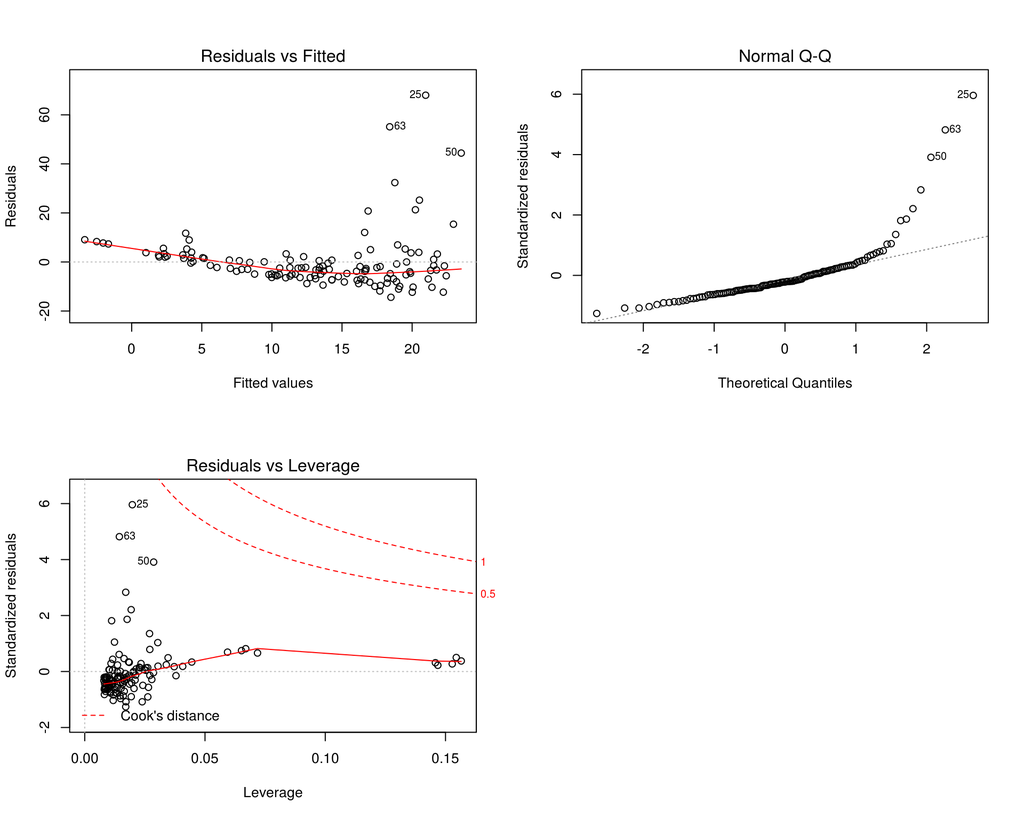

```r
par(mfrow = c(2,2))
plot(my_best_model, which = c(1,2,5))
```

All the plots indicates that there are problems with this model.

1. Residuals vs fitted values is a plot that can be used to check the model assumption that the residuals (ε, size of the errors) do not depend on explanatory variables but only on random variability (in other words, residuals has a constant variance . In the plot the dots should be randomly distributed, otherwise it indicates a problem.
   1. In this case there can be seen a clear pattern on the right side of the picture.
2. Normal QQ-plot can be used to check, are residuals distributed normally. If they are, the dots should be aligned on the line.
   1. In these cases there are about ten outliers.
3. Residuals vs leverage is a plot that can be used to assess how big effect a single observation has to the model. In the plot a big x value means exceptionally big effect and refers to that the observation in question might be an outlier (*Note*: if an exceptional value (y axle) of target variable is near the mean of explanatory variables of the model, the observation does not have so big (leverage) effect to the regression line).
   1. There is clearly about five exceptional values with strong leverage and also about five other exceptional observations.

# Conclusions and discussion

The model fitted could not pass the graphical model validation, so this exercise should be done again with refined data and methods. Still the model seems to be realistic, as it predicts extreme crime rates are more probable nearer the densely populated employment centres (*dis*) and where the values of homes (*medv*) are lower. Removing some outliers the distributions in scatter plots would become more linear (now approaching asymptotically the axes). Unfortunately this regression analysis could not find any more socially interesting predictors among high crime rate towns. For example, from the original Boston dataset it could be seen that towns with the most highest crime rates had also the highest or second highest values of *tax* variable. Excerpt from the original article mentioned in the introduction of this work Harrison and Rubinfeld (1978) describes the *tax* variable:

> Full value property tax rate ($/$1O,OOO), measures the cost of public services in each community. Nominal tax rates were corrected by local assessment ratios to yield the full value tax rate for each town. The coefficient of this variable should be negative.

The last statement means that the lower the *tax* the higher is the housing values (*medv*) to be expected in the area. Crime obviously increases the cost of public services, so crim and tax are correlated. From the more succesful LDA analysis in RStudio exercise 4 *tax* seemed to classify medium–high crime areas but not at all high crime areas.

The last time this document was knitted: Tue Dec 19 07:57:01 2017.